# Taller 4 Seleccion automatica de modelos

Kevin Zarama - Cristhian Castillo

25/3/2021

Leer datos del dataset

```r
data <- na.omit(read.csv("DatosTaller4.csv", row.names=1))
```

Primeras columnas del dataset

```r
head(data)
```

```
##   population householdsize racepctblack racePctWhite racePctAsian racePctHisp
## 1       0.19          0.33         0.02         0.90         0.12        0.17
## 2       0.00          0.16         0.12         0.74         0.45        0.07
## 3       0.00          0.42         0.49         0.56         0.17        0.04
## 4       0.04          0.77         1.00         0.08         0.12        0.10
## 5       0.01          0.55         0.02         0.95         0.09        0.05
## 6       0.02          0.28         0.06         0.54         1.00        0.25
##   agePct12t21 agePct12t29 agePct16t24 agePct65up numbUrban pctUrban medIncome
## 1        0.34        0.47        0.29       0.32      0.20      1.0      0.37
## 2        0.26        0.59        0.35       0.27      0.02      1.0      0.31
## 3        0.39        0.47        0.28       0.32      0.00      0.0      0.30
## 4        0.51        0.50        0.34       0.21      0.06      1.0      0.58
## 5        0.38        0.38        0.23       0.36      0.02      0.9      0.50
## 6        0.31        0.48        0.27       0.37      0.04      1.0      0.52
##   pctWWage pctWFarmSelf pctWInvInc pctWSocSec pctWPubAsst pctWRetire medFamInc
```

[output cut: 118 more lines]

Dimensiones del dataset

```r
dim(data)
```

```
## [1] 1993  101
```

Modelo con todas las variables explicativas

```r
max.model <- lm(ViolentCrimesPerPop ~ ., data)
summary(max.model)
```

```
##
## Call:
## lm(formula = ViolentCrimesPerPop ~ ., data = data)
##
## Residuals:
##      Min       1Q   Median       3Q      Max
## -0.51899 -0.07143 -0.01399  0.05068  0.74897
##
## Coefficients:
##                        Estimate Std. Error t value Pr(>|t|)
## (Intercept)            0.550392   0.202981   2.712 0.006758 **
## population             0.183963   0.397277   0.463 0.643374
## householdsize         -0.022316   0.086223  -0.259 0.795805
## racepctblack           0.204934   0.051131   4.008 6.36e-05 ***
## racePctWhite          -0.049156   0.058758  -0.837 0.402930
## racePctAsian          -0.014430   0.034339  -0.420 0.674378
## racePctHisp            0.060876   0.053459   1.139 0.254958
## agePct12t21            0.110357   0.105811   1.043 0.297098
## agePct12t29           -0.229218   0.156243  -1.467 0.142527
## agePct16t24           -0.130162   0.164148  -0.793 0.427902
## agePct65up             0.049744   0.103390   0.481 0.630477
## numbUrban             -0.296443   0.386974  -0.766 0.443741
## pctUrban               0.046701   0.015626   2.989 0.002838 **
## medIncome             -0.199829   0.172569  -1.158 0.247026
## pctWWage              -0.201574   0.089238  -2.259 0.024006 *
## pctWFarmSelf           0.048751   0.020129   2.422 0.015531 *
## pctWInvInc            -0.173121   0.067552  -2.563 0.010461 *
## pctWSocSec             0.076175   0.107032   0.712 0.476738
## pctWPubAsst            0.004959   0.046012   0.108 0.914184
## pctWRetire            -0.090002   0.036811  -2.445 0.014577 *
## medFamInc              0.287979   0.160277   1.797 0.072534 .
## perCapInc              0.095516   0.188628   0.506 0.612656
## whitePerCap           -0.351016   0.152407  -2.303 0.021379 *
## blackPerCap           -0.028755   0.025434  -1.131 0.258375
## indianPerCap          -0.035717   0.019399  -1.841 0.065752 .
## AsianPerCap            0.021647   0.018911   1.145 0.252495
## OtherPerCap            0.043807   0.018712   2.341 0.019330 *
## HispPerCap             0.035728   0.024893   1.435 0.151375
## NumUnderPov            0.111157   0.138021   0.805 0.420709
## PctPopUnderPov        -0.172144   0.062714  -2.745 0.006110 **
```

[output cut: 62 more lines]

```
## PctForeignBorn         0.117498   0.089879   1.307 0.191274
## PctBornSameState       0.006292   0.041574   0.151 0.879723
## PctSameHouse85        -0.017613   0.057538  -0.306 0.759561
## PctSameCity85          0.025766   0.038079   0.677 0.498708
## PctSameState85         0.013157   0.042678   0.308 0.757890
## LandArea               0.022543   0.049046   0.460 0.645839
## PopDens               -0.012622   0.030345  -0.416 0.677507
## PctUsePubTrans        -0.042011   0.023100  -1.819 0.069116 .
## LemasPctOfficDrugUn    0.024716   0.015451   1.600 0.109838
## ---
## Signif. codes:  0 '***' 0.001 '**' 0.01 '*' 0.05 '.' 0.1 ' ' 1
##
## Residual standard error: 0.1319 on 1892 degrees of freedom
## Multiple R-squared:  0.6957, Adjusted R-squared:  0.6796
## F-statistic: 43.26 on 100 and 1892 DF,  p-value: < 2.2e-16
```

## Stepwise forward

```r
max.model.formula <- formula(max.model)
fwd.model <- regsubsets(x=max.model.formula, y=ViolentCrimesPerPop, data=data, nvmax=100000, method="forward")
```

Graficar el resultado del stepwise para elegir el mejor modelo.

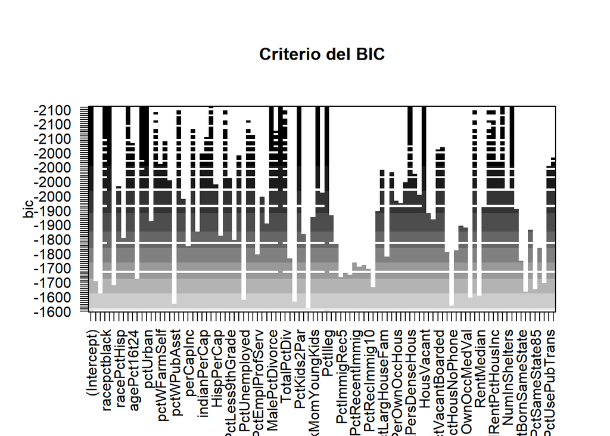

```r
plot(fwd.model, scale="bic", main="Criterio del BIC")
```

El mejor modelo es:

```r
best.fwd.model <- summary(fwd.model)
best.fwd.model.bic <- which.min(best.fwd.model$bic)
vars.fwd.model <- names(coef(fwd.model, best.fwd.model.bic))
formula.best.fwd <- as.formula(paste("ViolentCrimesPerPop ~ 1 +", paste(vars.fwd.model[2:length(vars.fwd.model)], collapse=" + "), sep=""))
best.model.fwd <- lm(formula.best.fwd, data)
summary(best.model.fwd)
```

```
##
## Call:
## lm(formula = formula.best.fwd, data = data)
##
## Residuals:
##      Min       1Q   Median       3Q      Max
## -0.52340 -0.07182 -0.01528  0.04803  0.79155
##
## Coefficients:
##                        Estimate Std. Error t value Pr(>|t|)
## (Intercept)            0.349596   0.063551   5.501 4.27e-08 ***
## racepctblack           0.156815   0.036198   4.332 1.55e-05 ***
## racePctWhite          -0.031108   0.041315  -0.753 0.451573
## agePct12t29           -0.085176   0.024482  -3.479 0.000514 ***
## numbUrban             -0.232185   0.061249  -3.791 0.000155 ***
## pctUrban               0.042788   0.007779   5.501 4.28e-08 ***
## OtherPerCap            0.047909   0.017110   2.800 0.005159 **
## MalePctDivorce         0.166182   0.049088   3.385 0.000725 ***
## FemalePctDiv          -0.065177   0.051159  -1.274 0.202810
## PctKids2Par           -0.314220   0.044519  -7.058 2.33e-12 ***
## PctWorkMom            -0.082234   0.019665  -4.182 3.02e-05 ***
## PctIlleg               0.200797   0.036819   5.454 5.56e-08 ***
## PctPersDenseHous       0.191815   0.031070   6.174 8.07e-10 ***
## HousVacant             0.299080   0.048279   6.195 7.08e-10 ***
## MedOwnCostPctIncNoMtg -0.056238   0.017584  -3.198 0.001404 **
## NumStreet              0.203305   0.040282   5.047 4.90e-07 ***
## ---
## Signif. codes:  0 '***' 0.001 '**' 0.01 '*' 0.05 '.' 0.1 ' ' 1
##
## Residual standard error: 0.1351 on 1977 degrees of freedom
## Multiple R-squared:  0.6665, Adjusted R-squared:  0.664
## F-statistic: 263.4 on 15 and 1977 DF,  p-value: < 2.2e-16
```

## Stepwise backward

```r
bwd.model <- regsubsets(x=formula(max.model), y=ViolentCrimesPerPop, data=data, nvmax=100000, method="backward")
```

Graficar el resultado del backward para elegir el mejor modelo

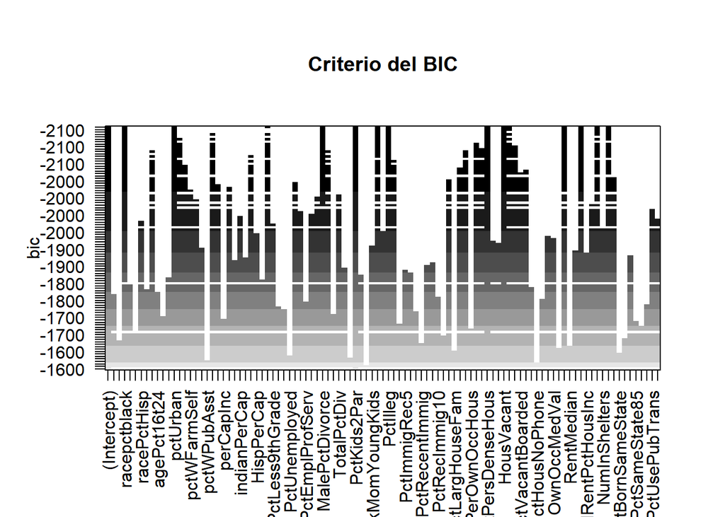

```r
plot(bwd.model, scale="bic", main="Criterio del BIC")
```

El mejor modelo es:

```r
best.bwd.model <- summary(bwd.model)
best.bwd.model.bic <- which.min(best.bwd.model$bic)
vars.bwd.model <- names(coef(bwd.model, best.bwd.model.bic))
vars.bwd.model[-1]
```

```
##  [1] "racepctblack"          "pctUrban"              "PctPopUnderPov"
##  [4] "MalePctDivorce"        "PctKids2Par"           "PctWorkMom"
##  [7] "PctIlleg"              "PctPersDenseHous"      "HousVacant"
## [10] "PctHousOccup"          "RentLowQ"              "MedRent"
## [13] "MedOwnCostPctIncNoMtg" "NumStreet"
```

```r
formula.best.bwd <- as.formula(paste("ViolentCrimesPerPop ~ 1 +", paste(vars.bwd.model[2:length(vars.bwd.model)], collapse=" + "), sep=""))
best.model.bwd <- lm(formula.best.bwd, data)
summary(best.model.bwd)
```

```
##
## Call:
## lm(formula = formula.best.bwd, data = data)
##
## Residuals:
##      Min       1Q   Median       3Q      Max
## -0.48630 -0.07299 -0.01319  0.04983  0.79404
##
## Coefficients:
##                        Estimate Std. Error t value Pr(>|t|)
## (Intercept)            0.385258   0.061867   6.227 5.79e-10 ***
## racepctblack           0.176631   0.022526   7.841 7.23e-15 ***
## pctUrban               0.034542   0.008201   4.212 2.64e-05 ***
## PctPopUnderPov        -0.090200   0.031401  -2.872 0.004116 **
## MalePctDivorce         0.135755   0.029920   4.537 6.04e-06 ***
## PctKids2Par           -0.350221   0.053264  -6.575 6.20e-11 ***
## PctWorkMom            -0.103310   0.020673  -4.997 6.33e-07 ***
## PctIlleg               0.182250   0.037079   4.915 9.60e-07 ***
## PctPersDenseHous       0.207602   0.020226  10.264  < 2e-16 ***
## HousVacant             0.112247   0.029209   3.843 0.000125 ***
## PctHousOccup          -0.067171   0.019818  -3.389 0.000714 ***
## RentLowQ              -0.236667   0.048917  -4.838 1.41e-06 ***
## MedRent                0.243995   0.051299   4.756 2.11e-06 ***
## MedOwnCostPctIncNoMtg -0.065854   0.017613  -3.739 0.000190 ***
## NumStreet              0.173223   0.039052   4.436 9.68e-06 ***
## ---
## Signif. codes:  0 '***' 0.001 '**' 0.01 '*' 0.05 '.' 0.1 ' ' 1
##
## Residual standard error: 0.1348 on 1978 degrees of freedom
## Multiple R-squared:  0.668,  Adjusted R-squared:  0.6657
## F-statistic: 284.3 on 14 and 1978 DF,  p-value: < 2.2e-16
```

## Prueba mejor modelo

El modelo 1, que se selecciono con el stepwise forward, tiene 15 variables explicativas y el modelo 2, que se selecciono con el stepwise backward, tiene 14 variables explicativas. A continuacion se va a probar cual de los dos es el mejor modelo.

```r
jtest(best.model.fwd, best.model.bwd)
```

```
## J test
##
## Model 1: ViolentCrimesPerPop ~ 1 + racepctblack + racePctWhite + agePct12t29 +
##     numbUrban + pctUrban + OtherPerCap + MalePctDivorce + FemalePctDiv +
##     PctKids2Par + PctWorkMom + PctIlleg + PctPersDenseHous +
##     HousVacant + MedOwnCostPctIncNoMtg + NumStreet
## Model 2: ViolentCrimesPerPop ~ 1 + racepctblack + pctUrban + PctPopUnderPov +
##     MalePctDivorce + PctKids2Par + PctWorkMom + PctIlleg + PctPersDenseHous +
##     HousVacant + PctHousOccup + RentLowQ + MedRent + MedOwnCostPctIncNoMtg +
##     NumStreet
##                 Estimate Std. Error t value  Pr(>|t|)
## M1 + fitted(M2)  0.77903    0.15821  4.9241 9.178e-07 ***
## M2 + fitted(M1)  0.69705    0.17724  3.9328 8.685e-05 ***
## ---
## Signif. codes:  0 '***' 0.001 '**' 0.01 '*' 0.05 '.' 0.1 ' ' 1
```

```r
coxtest(best.model.fwd, best.model.bwd)
```

```
## Cox test
##
## Model 1: ViolentCrimesPerPop ~ 1 + racepctblack + racePctWhite + agePct12t29 +
##     numbUrban + pctUrban + OtherPerCap + MalePctDivorce + FemalePctDiv +
##     PctKids2Par + PctWorkMom + PctIlleg + PctPersDenseHous +
##     HousVacant + MedOwnCostPctIncNoMtg + NumStreet
## Model 2: ViolentCrimesPerPop ~ 1 + racepctblack + pctUrban + PctPopUnderPov +
##     MalePctDivorce + PctKids2Par + PctWorkMom + PctIlleg + PctPersDenseHous +
##     HousVacant + PctHousOccup + RentLowQ + MedRent + MedOwnCostPctIncNoMtg +
##     NumStreet
##                 Estimate Std. Error z value  Pr(>|z|)
## fitted(M1) ~ M2  -20.193     2.7468 -7.3513 1.962e-13 ***
## fitted(M2) ~ M1  -15.328     2.8515 -5.3752 7.650e-08 ***
## ---
## Signif. codes:  0 '***' 0.001 '**' 0.01 '*' 0.05 '.' 0.1 ' ' 1
```

Con la prueba j con un 95% de confianza y la prueba cox con un 95% de confianza no es posible determinar cual es el mejor modelo entre los dos. Se observa que el modelo 1 tiene algunas variables no significativas, por lo cual se eliminaran a continuacion.

```r
remove_not_significant <- function(modelo, p){
  all_vars <- all.vars(formula(modelo))[-1]
  dep_var <- all.vars(formula(modelo))[1]
  summ <- summary(modelo)
  pvals <- summ[[4]][,4]
  not_signif <- character()
  not_signif <- names(which(pvals > p))

  while(length(not_signif) > 0){
    all_vars <- all_vars[!all_vars %in% not_signif[1]]
    myForm <- as.formula(paste(paste(dep_var, " ~"), paste(all_vars, collapse=" + "), sep=""))
    modelo <- lm(myForm, data)
    summ <- summary(modelo)
    pvals <- summ[[4]][, 4]
    not_signif <- character()
    not_signif <- names(which(pvals > p))
    not_signif <- not_signif[!not_signif %in% "(Intercept)"]
  }
  modelo.limpio <- modelo
  return(modelo.limpio)
}
best.model.fwd.clean <- remove_not_significant(best.model.fwd, 0.01)
summary(best.model.fwd.clean)
```

```
##
## Call:
## lm(formula = myForm, data = data)
##
## Residuals:
##      Min       1Q   Median       3Q      Max
## -0.52158 -0.07212 -0.01515  0.04849  0.80318
##
## Coefficients:
##                        Estimate Std. Error t value Pr(>|t|)
## (Intercept)            0.305329   0.046854   6.517 9.10e-11 ***
## racepctblack           0.175717   0.022725   7.732 1.67e-14 ***
## agePct12t29           -0.087760   0.024414  -3.595 0.000333 ***
## numbUrban             -0.233691   0.060514  -3.862 0.000116 ***
## pctUrban               0.041962   0.007745   5.418 6.77e-08 ***
## OtherPerCap            0.047839   0.017021   2.811 0.004993 **
## MalePctDivorce         0.113721   0.028064   4.052 5.27e-05 ***
## PctKids2Par           -0.302777   0.043699  -6.929 5.73e-12 ***
## PctWorkMom            -0.083256   0.019647  -4.238 2.36e-05 ***
## PctIlleg               0.208706   0.036394   5.735 1.13e-08 ***
## PctPersDenseHous       0.203830   0.019191  10.621  < 2e-16 ***
## HousVacant             0.301285   0.047840   6.298 3.71e-10 ***
## MedOwnCostPctIncNoMtg -0.054101   0.017337  -3.121 0.001831 **
## NumStreet              0.203368   0.040248   5.053 4.75e-07 ***
## ---
## Signif. codes:  0 '***' 0.001 '**' 0.01 '*' 0.05 '.' 0.1 ' ' 1
##
## Residual standard error: 0.1351 on 1979 degrees of freedom
## Multiple R-squared:  0.6662, Adjusted R-squared:  0.664
## F-statistic: 303.8 on 13 and 1979 DF,  p-value: < 2.2e-16
```

```r
jtest(best.model.fwd.clean, best.model.bwd)
```

```
## J test
##
## Model 1: ViolentCrimesPerPop ~ racepctblack + agePct12t29 + numbUrban +
##     pctUrban + OtherPerCap + MalePctDivorce + PctKids2Par + PctWorkMom +
##     PctIlleg + PctPersDenseHous + HousVacant + MedOwnCostPctIncNoMtg +
##     NumStreet
## Model 2: ViolentCrimesPerPop ~ 1 + racepctblack + pctUrban + PctPopUnderPov +
##     MalePctDivorce + PctKids2Par + PctWorkMom + PctIlleg + PctPersDenseHous +
##     HousVacant + PctHousOccup + RentLowQ + MedRent + MedOwnCostPctIncNoMtg +
##     NumStreet
##                 Estimate Std. Error t value  Pr(>|t|)
## M1 + fitted(M2)  0.78434    0.15813  4.9599 7.654e-07 ***
## M2 + fitted(M1)  0.67968    0.18264  3.7214 0.0002036 ***
## ---
## Signif. codes:  0 '***' 0.001 '**' 0.01 '*' 0.05 '.' 0.1 ' ' 1
```

```r
coxtest(best.model.fwd.clean, best.model.bwd)
```

```
## Cox test
##
## Model 1: ViolentCrimesPerPop ~ racepctblack + agePct12t29 + numbUrban +
##     pctUrban + OtherPerCap + MalePctDivorce + PctKids2Par + PctWorkMom +
##     PctIlleg + PctPersDenseHous + HousVacant + MedOwnCostPctIncNoMtg +
##     NumStreet
## Model 2: ViolentCrimesPerPop ~ 1 + racepctblack + pctUrban + PctPopUnderPov +
##     MalePctDivorce + PctKids2Par + PctWorkMom + PctIlleg + PctPersDenseHous +
##     HousVacant + PctHousOccup + RentLowQ + MedRent + MedOwnCostPctIncNoMtg +
##     NumStreet
##                 Estimate Std. Error z value  Pr(>|z|)
## fitted(M1) ~ M2  -20.292     2.7229 -7.4523 9.171e-14 ***
## fitted(M2) ~ M1  -14.331     2.8470 -5.0337 4.810e-07 ***
## ---
## Signif. codes:  0 '***' 0.001 '**' 0.01 '*' 0.05 '.' 0.1 ' ' 1
```

De igual forma no se puede concluir con estos dos modelos en ninguna de las dos pruebas, por lo cual se hara uso de el r^2, AIC y BIC adj en la comparacion de los modelos para poder concluir la prueba.

```r
summary(best.model.fwd.clean)$adj.r.square
```

```
## [1] 0.6639862
```

```r
summary(best.model.bwd)$adj.r.squared
```

```
## [1] 0.6656598
```

```r
AIC(best.model.fwd.clean, best.model.bwd)
```

```
##                      df       AIC
## best.model.fwd.clean 15 -2307.465
## best.model.bwd       16 -2316.424
```

```r
BIC(best.model.fwd.clean, best.model.bwd)
```

```
##                      df       BIC
## best.model.fwd.clean 15 -2223.504
## best.model.bwd       16 -2226.865
```

Con lo cual se puede concluir que el mejor de los modelo es el: modelo best.model.bwd, debido a que el r^2, y el AIC muestran que este es el mejor modelo, el cual tiene las siguientes variables explicativas:

```r
names(coef(best.model.bwd))[-1]
```

```
##  [1] "racepctblack"          "pctUrban"              "PctPopUnderPov"
##  [4] "MalePctDivorce"        "PctKids2Par"           "PctWorkMom"
##  [7] "PctIlleg"              "PctPersDenseHous"      "HousVacant"
## [10] "PctHousOccup"          "RentLowQ"              "MedRent"
## [13] "MedOwnCostPctIncNoMtg" "NumStreet"
```